# **MATH 3190 Homework 4**

# Problem 2 (26 points)

Suppose $\boldsymbol{x} = (x_1,\dots, x_n )^T$ are independent and identically distributed random variables with probability density function (pdf) given by
$$f(x_i|\theta) = \theta(1-x_i)^{\theta-1};\ \ 0\le x_i< 1,\ 0<\theta<\infty,\ i=1,\dots,n$$

### Part a (4 points)

Using ggplot, plot the probability density function (pdf) for an individual $x_i$ given $\theta=0.5$ and then again for $\theta=5$.

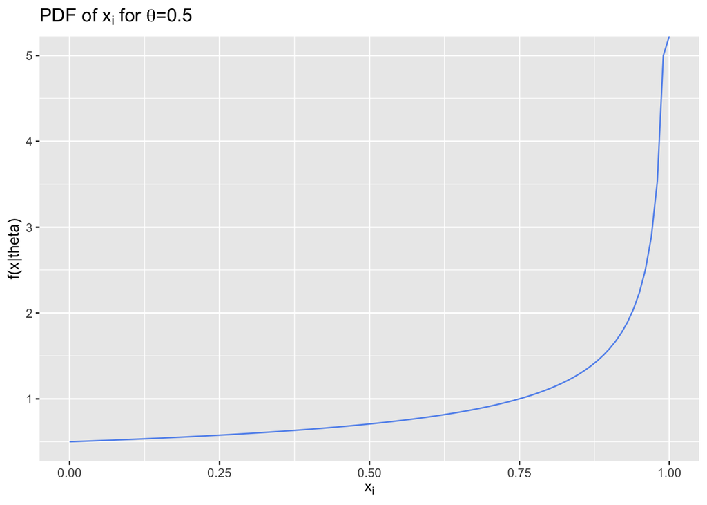

```r
library(ggplot2)
theta <- 0.5
ggplot(data.frame(x=c(0, 1)), aes(x=x))+
  stat_function(
    fun = function(x) theta * (1-x)^(theta-1),
    color="cornflowerblue"
  )+
  coord_cartesian(xlim = c(0, 0.9999999))+
  labs(
    title= expression(paste("PDF of ", x[i], " for ", theta, "=0.5")),
    x= expression(x[i]),
    y= "f(x|theta)"
  )
```

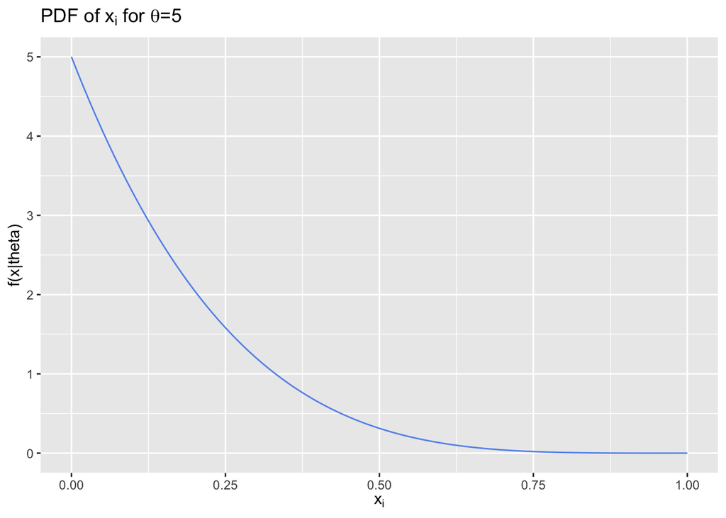

```r
theta <- 5
ggplot(data.frame(x=c(0, 1)), aes(x=x))+
  stat_function(
    fun = function(x) theta * (1-x)^(theta-1),
    color="cornflowerblue"
  )+
  coord_cartesian(xlim = c(0, 0.9999999))+
  labs(
    title= expression(paste("PDF of ", x[i], " for ", theta, "=5")),
    x= expression(x[i]),
    y= "f(x|theta)"
  )
```

### Part b (5 points)

Give the likelihood $L(\theta|\boldsymbol{x})$ and log-likelihood $\ell(\theta|\boldsymbol{x})$ functions in this situation.

$$L(\theta|\boldsymbol{x})=\theta^n(\prod_{i=1}^{n}(1-x_i))^{\theta-1}$$

$$\ell(\theta|\boldsymbol{x})=nln(\theta)+(\theta-1)\sum_{i=1}^{n}ln(1-x_i)$$

### Part c (5 points)

Find the Maximum Likelihood Estimator (MLE) $\hat{\theta}$ for $\theta$.

$$\frac{d\ell}{d\theta}=\frac{n}{\theta}+\sum_{i=1}^{n}ln(1-x_i)$$

set equal to 0 and solve for theta

$$\hat{\theta}=\dfrac{n}{-\sum_{i=1}^{n}ln(1-x_i)}$$

### Part d (3 points)

Show that your estimator is in fact a maximum. That is, check the second derivative of the log-likelihood.

$$\frac{d^2\ell}{d\theta^2}=-\frac{n}{\theta^2}$$

Since both n and theta squared must be positive, the second derivative shown above will always be negative, ensuring that our estimator must be a maximum

### Part e (2 points)

Find the MLE if the data values are given below. Note, the actual $\theta$ value used to generate these data was $\theta=7.3$.

```r
x <- c(0.0194, 0.0053, 0.2488, 0.0456, 0.2059, 0.0992, 0.1168, 0.3705,
       0.2129, 0.018, 0.0464, 0.1401, 0.0759, 0.1588, 0.0334, 0.2931,
       0.0662, 0.2292, 0.1581, 0.3462, 0.035, 0.1086, 0.0793, 0.2095,
       0.1419, 0.1835, 0.1107, 0.0764, 0.1331, 0.042, 0.0911, 0.1608)

n <- length(x)

theta_hat <- n/(-sum(log(1-x)))

#This gives that theta_hat=6.7062
```

### Part f (7 points)

To get an idea of how variable the maximum likelihood estimator is in this case, let’s generate many samples of size 32 from this distribution (which is a Beta distribution with parameters $1$ and $\theta$, but you don’t really need to know that). We can do this by using `rbeta(32, 1, 7.3)`.

Using the code below, generate at least 10,000 samples this way, compute the MLE for each, and then plot a histogram of the values using ggplot. Plot a vertical line at the true $\theta$ value of 7.3 (you can use `geom_vline(xintercept = 7.3)` for this). On the plot somewhere, indicate what the standard deviation in those estimates is. Of course, this code is incomplete, so you’ll have to complete it. Once you do, make sure to change the `eval` option to `true`.

Once you’ve completed the code for the samples of size 32, repeat this but instead of taking samples of size 32, take samples of size 100. How does this change the histogram, where the distribution is centered, and the standard deviation of the estimates, if at all?

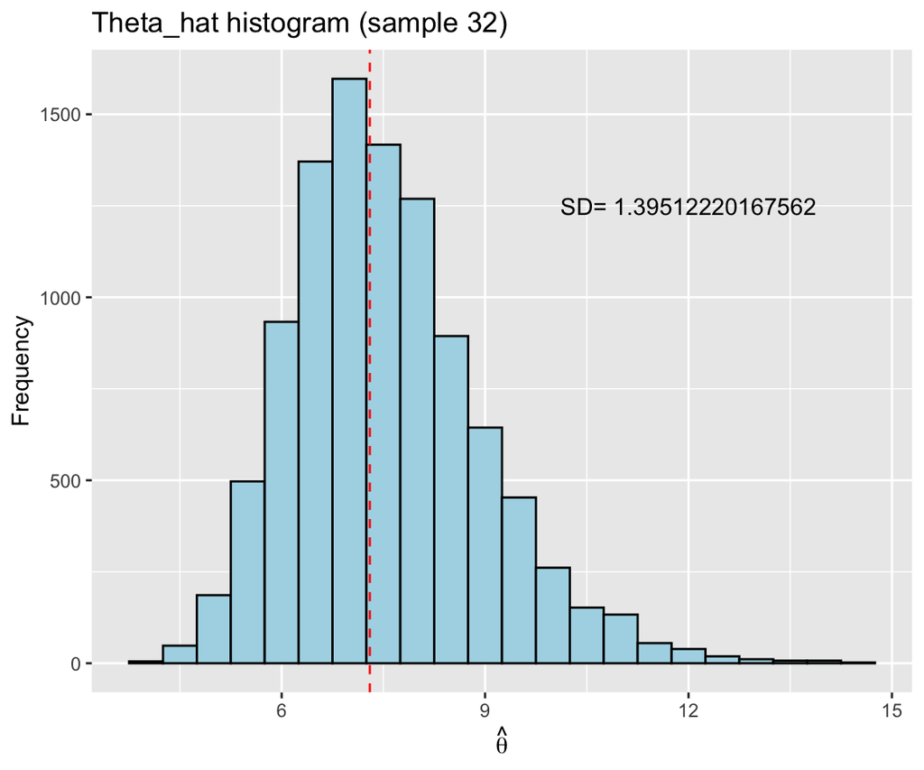

```r
set.seed(2026)
theta_hat <- rep(0, 10000)
for(i in 1:10000) {
  x_sim <- rbeta(32, 1, 7.3)
  theta_hat[i] <-length(x_sim)/(-sum(log(1-x_sim)))
}
theta_sd <- sd(theta_hat)

ggplot(data.frame(theta_hat=theta_hat), aes(x=theta_hat))+
  geom_histogram(binwidth = 0.5, fill="lightblue", color="black")+
  geom_vline(xintercept = 7.3, color="red", linetype="dashed")+
  annotate("text", x=12, y=1250, label=paste("SD=", theta_sd))+
  labs(title="Theta_hat histogram (sample 32)",
       x= expression(hat(theta)),
       y="Frequency")
```

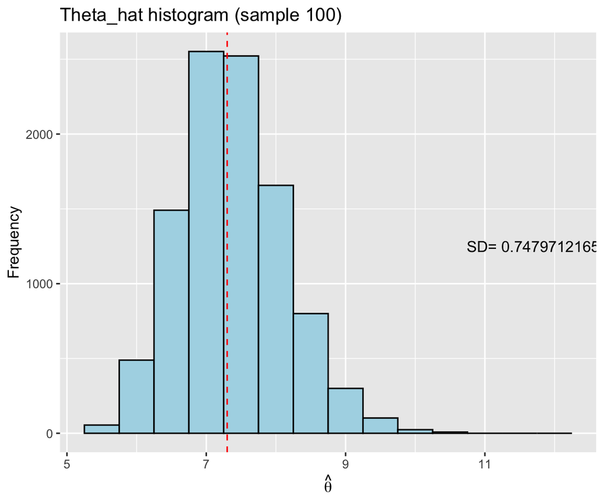

```r
set.seed(2026)
theta_hat <- rep(0, 10000)
for(i in 1:10000) {
  x_sim <- rbeta(100, 1, 7.3)
  theta_hat[i] <-length(x_sim)/(-sum(log(1-x_sim)))
}
theta_sd2 <- sd(theta_hat)

ggplot(data.frame(theta_hat=theta_hat), aes(x=theta_hat))+
  geom_histogram(binwidth = 0.5, fill="lightblue", color="black")+
  geom_vline(xintercept = 7.3, color="red", linetype="dashed")+
  annotate("text", x=12, y=1250, label=paste("SD=", theta_sd2))+
  labs(title="Theta_hat histogram (sample 100)",
       x= expression(hat(theta)),
       y="Frequency")
```

Taking samples of 100 caused the histogram to be a lot less spread out. The data is still centered around 7, but there is significantly less variation, making the MLE estimators in that area have much higher frequency. Additionally, our standard deviation was nearly cut in half.

# Problem 3 (31 points)

We implemented optimization to maximize the likelihood for a Poisson regression problem in the notes to estimate the $\beta$ (intercept and slope) values. Let’s do something similar for find the $\boldsymbol{\beta}$ vector by maximizing the likelihood in logistic regression.

In logistic regression, we attempt to predict the probability of a success for a given case. We can use the Bernoulli random variable for this. For a Bernoulli random variable, $P(Y=y_i) = p_i^{y_i}(1-p_i)^{1-y_i}$ for $y_i=0,1$ where $p_i$ is the probability of a success. In our case, for logistic regression, we have $\text{logit}(p_i)=\ln\left(\dfrac{p_i}{1-p_i}\right)=\mathbf{X}_i\boldsymbol{\beta}$. That means $p_i = \dfrac{\exp(\mathbf{X}_i\boldsymbol{\beta})}{1+\exp(\mathbf{X}_i\boldsymbol{\beta})}$.

The likelihood function, $L(\boldsymbol{\beta}|\mathbf{X},\boldsymbol{y})$, for the logistic regression for a sample of size $n$ is
$$\begin{align*}
L(\boldsymbol{\beta}|\mathbf{X},\boldsymbol{y}) &=\prod_{i=1}^n p_i^{y_i}(1-p_i)^{1-y_i}\\
&=\prod_{i=1}^n\left[\dfrac{\exp(\mathbf{X}_i\boldsymbol{\beta})}{1+\exp(\mathbf{X}_i\boldsymbol{\beta})}\right]^{y_i}\left(1-\left[\dfrac{\exp(\mathbf{X}_i\boldsymbol{\beta})}{1+\exp(\mathbf{X}_i\boldsymbol{\beta})}\right]\right)^{1-y_i}
\end{align*}$$

### Part a (7 points)

Using the above likelihood, show that the log likelihood function is
$$\ell(\boldsymbol{\beta}|\mathbf{X},\boldsymbol{y})=\sum_{i=1}^ny_i\ln\left(\dfrac{\exp(\mathbf{X}_i\boldsymbol{\beta})}{1+\exp(\mathbf{X}_i\boldsymbol{\beta})}\right) + \sum_{i=1}^n(1-y_i)\ln\left(\dfrac{1}{1+\exp(\mathbf{X}_i\boldsymbol{\beta})}\right)$$
and then show it can be equivalently written
$$\ell(\boldsymbol{\beta}|\mathbf{X},\boldsymbol{y}) = \sum_{i=1}^ny_i(\mathbf{X}_i\boldsymbol{\beta}) - \sum_{i=1}^n\ln\Big(1 + \exp(\mathbf{X}_i\boldsymbol{\beta})\Big)$$
using properties of logarithms.

Given that the likelihood function can be expressed as

$$\prod_{i=1}^n\left[\dfrac{\exp(\mathbf{X}_i\boldsymbol{\beta})}{1+\exp(\mathbf{X}_i\boldsymbol{\beta})}\right]^{y_i}\left(1-\left[\dfrac{\exp(\mathbf{X}_i\boldsymbol{\beta})}{1+\exp(\mathbf{X}_i\boldsymbol{\beta})}\right]\right)^{1-y_i}$$

We can split it into
$$\prod_{i=1}^n\left[\dfrac{\exp(\mathbf{X}_i\boldsymbol{\beta})}{1+\exp(\mathbf{X}_i\boldsymbol{\beta})}\right]^{y_i}\times\prod_{i=1}^n\left(1-\left[\dfrac{\exp(\mathbf{X}_i\boldsymbol{\beta})}{1+\exp(\mathbf{X}_i\boldsymbol{\beta})}\right]\right)^{1-y_i}$$
In order to find the log likelihood we take the log of the entire thing. Using the fact that ln(ab)=ln(a)+ln(b), we can change the products into summations. Additionally, since log exponents can be moved to be coefficients, the entire function can be rewritten as such:

$$\ell(\boldsymbol{\beta}|\mathbf{X},\boldsymbol{y})=\sum_{i=1}^ny_i\ln\left(\dfrac{\exp(\mathbf{X}_i\boldsymbol{\beta})}{1+\exp(\mathbf{X}_i\boldsymbol{\beta})}\right) + \sum_{i=1}^n(1-y_i)\ln\left(\dfrac{1}{1+\exp(\mathbf{X}_i\boldsymbol{\beta})}\right)$$
Using the fact that ln(a/b)=ln(a)-ln(b), this can be simplified to

$$\sum_{i=1}^ny_i\ln(\exp(\mathbf{X}_i\boldsymbol{\beta}))-\sum_{i=1}^ny_i\ln(1+\exp(\mathbf{X}_i\boldsymbol{\beta})) - \sum_{i=1}^n(1-y_i)\ln(1+\exp(\mathbf{X}_i\boldsymbol{\beta}))$$
Finally, we can cancel the ln and exp in the first summation and combine the last two to get a simplified function of

$$\ell(\boldsymbol{\beta}|\mathbf{X},\boldsymbol{y}) = \sum_{i=1}^ny_i(\mathbf{X}_i\boldsymbol{\beta}) - \sum_{i=1}^n\ln\Big(1 + \exp(\mathbf{X}_i\boldsymbol{\beta})\Big)$$

### Part b (6 points)

Find the gradient of the log likelihood if we have three $\beta$’s. That is, if $\mathbf{X}_i\boldsymbol{\beta}=\beta_0+\beta_1x_{i1}+\beta_2x_{i2}$.

For any and all values $\beta_j$, where j can be 0, 1, or 2, if we take the partial derivative of the first summation with respect to $\beta_j$, we get

$$\sum_{i=1}^{n}y_ix_{ij}$$
Concerning the second summation, the partial derivative for any and all values $\beta_j$ is

$$\sum_{i=1}^{n}x_{ij}\dfrac{\exp(\mathbf{X}_i\boldsymbol{\beta})}{1+\exp(\mathbf{X}_i\boldsymbol{\beta})}$$
Knowing the value of p_i this can be rewritten as

$$\sum_{i=1}^{n}x_{ij}p_i$$
Combining these gives

$$\sum_{i=1}^{n}y_ix_{ij}-\sum_{i=1}^{n}x_{ij}p_i=\sum_{i=1}^{n}x_{ij}(y_i-p_i)$$
So, the gradient for three parameters $\beta=(\beta_0, \beta_1, \beta_2)^T$ can be expressed as

$$\nabla_{\boldsymbol{\beta}}\ell(\boldsymbol{\beta})=\sum_{i=1}^{n}x_{ij}(y_i-p_i)$$

### Part c (4 points)

In Homework 3, Problem 2, part a, you read in the `adult` dataset (from the UC Irvine [database](https://archive.ics.uci.edu/dataset/2/adult)). This is the one that we used to predict whether a person makes over $50K a year based on some other variables. The data came from the Census Bureau in 1994 and can be found in the Data folder in my Math3190_S26 GitHub repo. More info on the dataset can be found in the “adult.names” file.

Read in the dataset and put column names like you did in HW 3. Then fit a logistic regression model using the `glm()` function that predicts salary from age/10 and sex. Note, we should divide the age by 10 in our model because this makes the gradient descent more stable (for whatever reason). We can divide by 10 in the `glm()` function by wrapping it in the `I()` function. Like this: `glm(salary ~ I(age/10) + sex, data = adult, family = binomial)`.

```r
library(tidyverse)
Adult <- read_csv("adult.data",
                  col_names = c("age",
                                "work_class",
                                "fnlwgt",
                                "education",
                                "education_num",
                                "marital_status",
                                "occupation",
                                "relationship",
                                "race",
                                "sex",
                                "capital_gain",
                                "capital_loss",
                                "hours_per_week",
                                "native_country",
                                "salary"))
Adult$salary <- factor(Adult$salary)
log_reg_salary <- glm(salary ~ I(age/10) + sex, data = Adult, family = binomial)
```

### Part d (4 points)

Define `y`, `x1`, and `x2`. `y` should be a vector of 0’s and 1’s with a 1 indicating that the person had a salary above $50,000. `x1` should be a vector that contains all of the age values (divided by 10) and then `x2` should be an indicator variable that indicates if the person is male or not. Taking columns from the matrix obtained using the `model.matrix()` function applied to your logistic regression model you fit in part c may be useful here.

```r
matrix <- model.matrix(log_reg_salary)

y <- as.numeric(Adult$salary==">50K")
x1 <- matrix[, "I(age/10)"]
x2 <- matrix[, "sexMale"]
```

### Part e (7 points)

Use the gradient descent function from problem 1 to find estimates for $\beta_0$, $\beta_1$, and $\beta_2$ for predicting salary from age and sex. Enter the following in your function:

- Use the vector `c(0, 0, 0)` as your starting point.
- Instead of starting the step size, $\gamma_k$, at 1, start it at 0.1 to save some time with the line search.
- Make sure the maximum number of iterations is at least 200.

You’ll know you did this right if the optimized values you end up with match (or are very close to) the estimates from your logistic regression model you fit in part c. This may take a minute or two to run, so you may want to cache this code chunk.

```r
X <- cbind(1, x1, x2)
loglik <- function(beta){
  beta <- X%*%beta
  sum(y*beta-log(1+exp(beta)))
}
grad_loglik <- function(beta){
  beta <- X%*%beta
  p <- exp(beta)/1+exp(beta)
  t(X)%*%(y-p)
}

gradient_desc(c(0, 0, 0),loglik, grad_loglik, max=T, maxit=300, step_size=0.1)
```

```
$x
[1] 0 0 0

$function_val
[1] -33854.69

$iters
[1] 1
```

### Part f (3 points)

Use the `optim()` function in **R** to find the estimate for the $\beta$’s here. This should be much faster since this function is much better optimized (no pun intended). The results here should also be very close to the numbers we obtained for the slopes in the model we fit in part c, but may not match exactly due to different stopping criteria.

```r
neg_loglik <- function(beta, X, y) {
  beta <- X %*% beta
  -sum(y * beta - log(1 + exp(beta)))
}
neg_gradient <- function(beta, X, y) {
  beta <- X %*% beta
  p <- exp(beta) / (1 + exp(beta))
  -(t(X) %*% (y - p))
}
optim(par=c(0,0,0), fn=neg_loglik, gr=neg_gradient, X=X, y=y)
```

```
$par
[1] -3.6304477  0.3829196  1.2420241

$value
[1] 24483.08

$counts
function gradient
     118       NA

$convergence
[1] 0

$message
NULL
```